# Problem Set 2

Marc Ishak

# Question 1

First, let’s load our preferred packages and load the data into R

```r
library(readr)
library(ggplot2)
library(dplyr)
library(gvlma)
library(broom)
library(gridExtra)
df <- read_csv("data/pset2/dynamic.csv")
```

## a

```r
regmod <- lm(static ~ dynamic, data = df)
regmod_sum <- summary(regmod)
regmod_sum
```

```
Call:
lm(formula = static ~ dynamic, data = df)

Residuals:
    Min      1Q  Median      3Q     Max
-493.00  -67.14   22.44   81.67  258.89

Coefficients:
             Estimate Std. Error t value Pr(>|t|)
(Intercept) 184.94127  123.38987   1.499    0.145
dynamic       0.85034    0.09153   9.290 4.76e-10 ***
---
Signif. codes:  0 â***â 0.001 â**â 0.01 â*â 0.05 â.â 0.1 â â 1

Residual standard error: 145.7 on 28 degrees of freedom
Multiple R-squared:  0.7551,    Adjusted R-squared:  0.7463
F-statistic: 86.31 on 1 and 28 DF,  p-value: 4.763e-10
```

Hence the regression formula is static = 184.9412723 + dynamic * 0.8503434 + $\epsilon$

## b

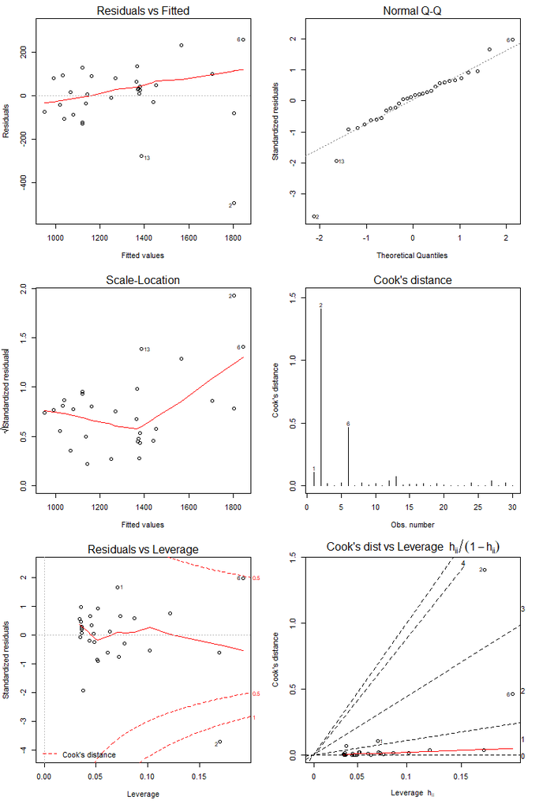

```r
par(mfrow = c(3,2))
plot(regmod, which = 1:6)
```

```r
gvlma(regmod)
```

```
Call:
lm(formula = static ~ dynamic, data = df)

Coefficients:
(Intercept)      dynamic
   184.9413       0.8503


ASSESSMENT OF THE LINEAR MODEL ASSUMPTIONS
USING THE GLOBAL TEST ON 4 DEGREES-OF-FREEDOM:
Level of Significance =  0.05

Call:
 gvlma(x = regmod)
```

|  | Value | p-value | Decision |
| --- | --- | --- | --- |
| Global Stat | 37.044310 | 1.763836e-07 | Assumptions NOT satisfied! |
| Skewness | 8.425266 | 3.700426e-03 | Assumptions NOT satisfied! |
| Kurtosis | 13.527375 | 2.351087e-04 | Assumptions NOT satisfied! |
| Link Function | 0.866232 | 3.520006e-01 | Assumptions acceptable. |
| Heteroscedasticity | 14.225437 | 1.621636e-04 | Assumptions NOT satisfied! |

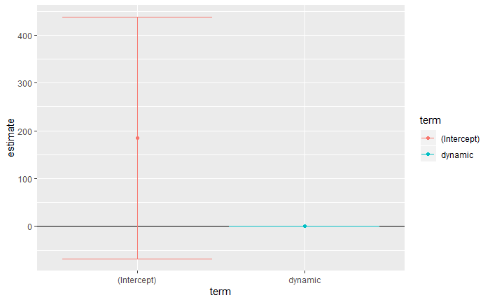

```r
tidy(regmod, conf.int = T) %>%
  ggplot(aes(term, estimate, color = term)) +
    geom_point() +
    geom_hline(yintercept = 0) +
    geom_errorbar(aes(ymin = conf.low, ymax = conf.high))
```

## c

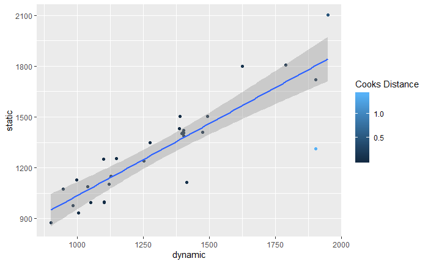

```r
augment(regmod) %>%
  ggplot(aes(dynamic, static)) +
    geom_point(aes(col = .cooksd)) +
    geom_smooth(method = "lm", se = 0.95) +
    labs(col = "Cooks Distance")
```

```r
paste0("Number of Outliers: ", (augment(regmod) %>%
  filter(.cooksd > qf(0.5,2,28)) %>%
  nrow()))
```

```
[1] "Number of Outliers: 1"
```

Yes, as there’s 1 point with a [cooks distance](https://en.wikipedia.org/wiki/Cook%27s_distance) > 0.7105929.

## d

Running a manual t test (testing the slope)

```r
t_val <- tidy(regmod)$statistic[2]
# calculating it manually with tidy(regmod)$estimate[2]/tidy(regmod)$std.error[2] also works
dfree = dim(df)[1] - 2
print((1 - pt(q =  t_val, df = dfree))*2)
```

```
[1] 4.763008e-10
```

Alternatively you could just read it off the summary/get it from the tided model

```r
tidy(regmod_sum)$p.value[2] #rounding diffrence smh
```

```
[1] 4.763007e-10
```

## Graph selections for data without outlier

We can clearly see that there exists an outlier in the original graph (cooks distance!!!). So here are the same calcs without the outlier. (This also is supposed to match more closely with my submitted stata version)

Calculating for the second graph (to match stata analysis)

```r
df2 <- augment(regmod) %>%
  filter(.cooksd < 1) %>%
  semi_join(df, .)
regmod2 <- lm(static ~ dynamic, data = df2)
regmod_sum2 <- summary(regmod2)
regmod_sum2
```

```
Call:
lm(formula = static ~ dynamic, data = df2)

Residuals:
     Min       1Q   Median       3Q      Max
-308.547  -37.693    1.274   66.782  170.959

Coefficients:
            Estimate Std. Error t value Pr(>|t|)
(Intercept) 23.43278   94.90303   0.247    0.807
dynamic      0.98807    0.07164  13.793 9.63e-14 ***
---
Signif. codes:  0 â***â 0.001 â**â 0.01 â*â 0.05 â.â 0.1 â â 1

Residual standard error: 105.7 on 27 degrees of freedom
Multiple R-squared:  0.8757,    Adjusted R-squared:  0.8711
F-statistic: 190.2 on 1 and 27 DF,  p-value: 9.634e-14
```

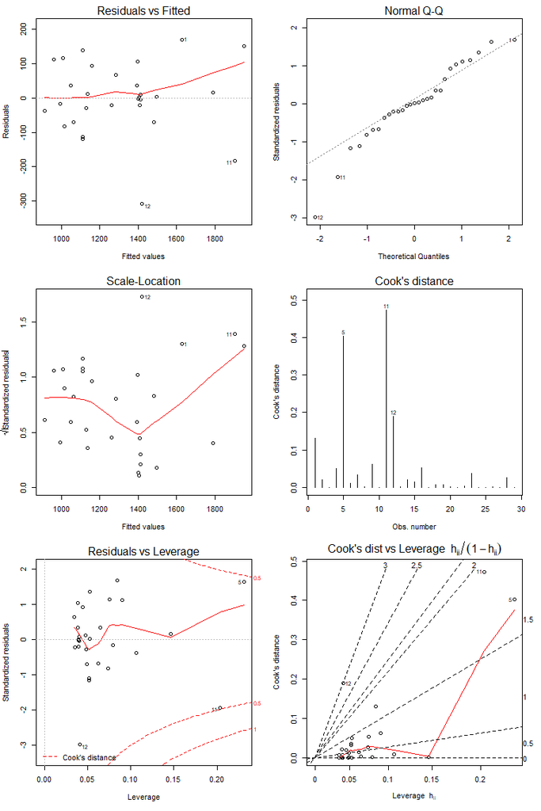

```r
par(mfrow = c(3,2))
plot(regmod2, which = 1:6)
```

```r
gvlma(regmod2)
```

```
Call:
lm(formula = static ~ dynamic, data = df2)

Coefficients:
(Intercept)      dynamic
    23.4328       0.9881


ASSESSMENT OF THE LINEAR MODEL ASSUMPTIONS
USING THE GLOBAL TEST ON 4 DEGREES-OF-FREEDOM:
Level of Significance =  0.05

Call:
 gvlma(x = regmod2)
```

|  | Value | p-value | Decision |
| --- | --- | --- | --- |
| Global Stat | 9.0186325 | 0.06063544 | Assumptions acceptable. |
| Skewness | 2.7367605 | 0.09806338 | Assumptions acceptable. |
| Kurtosis | 1.5631815 | 0.21120000 | Assumptions acceptable. |
| Link Function | 0.1895352 | 0.66330373 | Assumptions acceptable. |
| Heteroscedasticity | 4.5291553 | 0.03332206 | Assumptions NOT satisfied! |

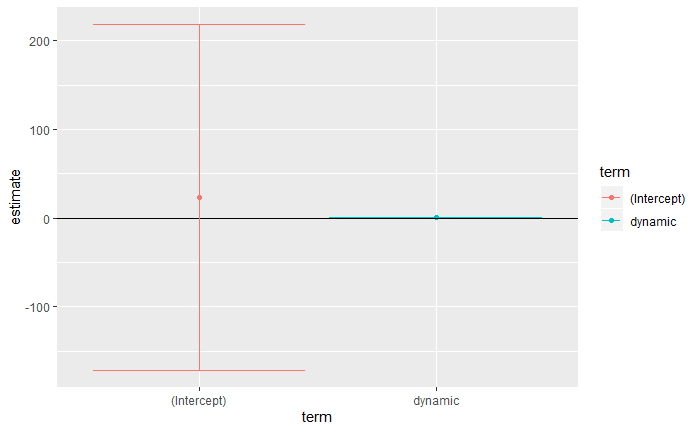

```r
tidy(regmod2, conf.int = T) %>%
  ggplot(aes(term, estimate, color = term)) +
    geom_point() +
    geom_hline(yintercept = 0) +
    geom_errorbar(aes(ymin = conf.low, ymax = conf.high))
```

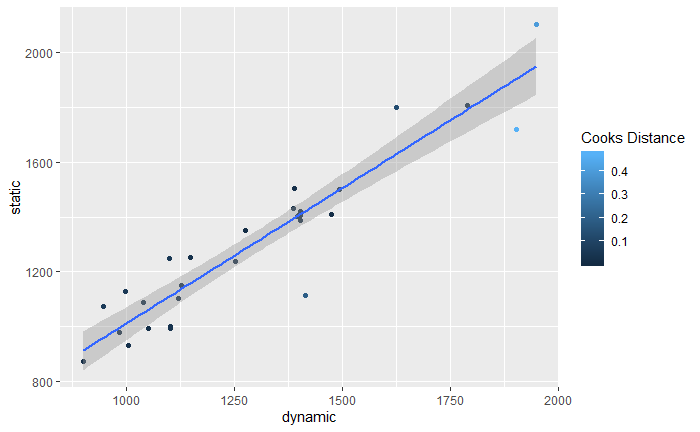

```r
augment(regmod2) %>%
  ggplot(aes(dynamic, static)) +
    geom_point(aes(col = .cooksd)) +
    geom_smooth(method = "lm", se = 0.95) +
    labs(col = "Cooks Distance")
```

```r
# Outlier count:
paste0("Number of Outliers: ", (augment(regmod2) %>%
  filter(.cooksd > qf(0.5,2,27)) %>%
  nrow()))
```

```
[1] "Number of Outliers: 0"
```

```r
t_val <- tidy(regmod2)$statistic[2]
# calculating it manually with tidy(regmod)$estimate[2]/tidy(regmod)$std.error[2] also works
dfree = nrow(df2) - 2
print((1 - pt(q =  t_val, df = dfree))*2)
```

```
[1] 9.636736e-14
```

Alternatively you could just read it off the summary/get it from the tided model

```r
tidy(regmod_sum2)$p.value[2] #rounding diffrence smh
```

```
[1] 9.634109e-14
```

# Question 2

The formula for a confidance interal is:
$$\hat{x} \pm z_{1-\alpha/2}\frac{s}{\sqrt{n}}$$

Hence as the size of $n$ gets larger the “band” of the confidance interval shrinks. A confidance interval is used to provide a predicion of the population parameter (like the mean) and not the entire data set (like a prediction interval). You can see it in the graphs below, which estimate the expected value (mean) of $y$ given $x$ witha 95% confidance interval (ie: $E(y|x)$):

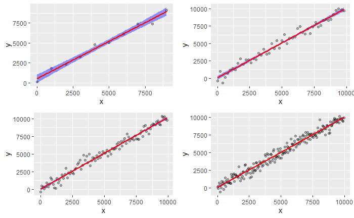

```r
plots <- lapply(c(10,50,100,200), function(n){
  points = data.frame(x = numeric(n), y = numeric(n))
  points$x <- seq(1,10000, 10000/n)
  points$y <- sapply(points$x, function(q){q + rnorm(mean = 0, sd = 500, n = 1)})
  ggplot(points,aes(x,y)) + geom_point(alpha = 0.3) + geom_smooth(method = "lm", se = 0.95, col = "red", fill = "blue")
})
nCol <- floor(sqrt(length(plots)))
do.call("grid.arrange", c(plots, ncol=nCol))
```